# Analysis of customer churn

# 7 Interpretation

In the following chapter, we will make the decisions of our models for our chosen instance (see Business Understanding) directly visible by providing first the decision tree path of our instance and second, running three XAI methods (SHAP, LIME, Anchors) on our best Random Forest Classifier.

```python
# Setup
best_rf = rf_results.best_estimator_
fitted_preprocessor = best_rf.named_steps["preprocessor"]
fitted_classifier   = best_rf.named_steps["classifier"]
xai_feature_names = fitted_preprocessor.get_feature_names()

X_train_raw = X_train.values
X_test_raw  = X_test.values
feature_names_raw = X_train.columns.tolist()

categorical_names = {}
for idx in cat_indices:
    col = X_train.columns[idx]
    categorical_names[idx] = sorted(X_train[col].astype(str).unique().tolist())

X_train_transformed = fitted_preprocessor.transform(X_train)
X_test_transformed  = fitted_preprocessor.transform(X_test)

label_encoders = {}

def predict_fn(X_numeric):
    """Predict class labels (int array) from label-encoded numeric input."""
    X_df = pd.DataFrame(X_numeric, columns=feature_names_raw)
    for idx in cat_indices:
        col = X_train.columns[idx]
        X_df[col] = label_encoders[col].inverse_transform(X_df[col].astype(int))
    return X_df

def predict_fn_lime(X_numeric):
    return best_rf.predict_proba(predict_fn(X_numeric))

def predict_fn_anchors(X_numeric):
    return best_rf.predict(predict_fn(X_numeric)).astype(int)


y_proba_test = best_rf.predict_proba(X_test)[:, 1]
churner_idx  = np.argmax(y_proba_test)
instance_raw = X_test_raw[[churner_idx]]
instance_transformed = X_test_transformed[[churner_idx]]


print(f"Explaining instance index {churner_idx}")
print(f"Predicted churn probability: {y_proba_test[churner_idx] * 100 :.2f}%")
```

```
Explaining instance index 1109
Predicted churn probability: 88.05%
```

```python
X_test.iloc[[churner_idx]]
```

|  | gender | SeniorCitizen | Partner | Dependents | tenure | PhoneService | MultipleLines | InternetService | OnlineSecurity | OnlineBackup | DeviceProtection | TechSupport | StreamingTV | StreamingMovies | Contract | PaperlessBilling | PaymentMethod | MonthlyCharges | TotalCharges |
| --- | --- | --- | --- | --- | --- | --- | --- | --- | --- | --- | --- | --- | --- | --- | --- | --- | --- | --- | --- |
| 4585 | Female | 1 | No | No | 1 | Yes | Yes | Fiber optic | No | No | No | No | No | Yes | Month-to-month | Yes | Electronic check | 85.05 | 85.05 |

## 7.1 Intrinsic Interpretation

```python
best_dt_pipeline = dt_results.best_estimator_
fitted_dt_preprocessor = best_dt_pipeline.named_steps["preprocessor"]
fitted_dt_classifier   = best_dt_pipeline.named_steps["classifier"]

dt_feature_names = fitted_dt_preprocessor.get_feature_names()
```

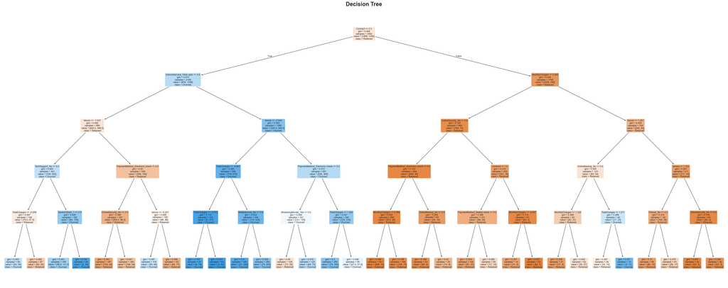

```python
fig, ax = plt.subplots(figsize=(40, 16))

plot_tree(
    fitted_dt_classifier,
    feature_names=dt_feature_names,
    class_names=["Retained", "Churned"],
    filled=True,
    rounded=True,
    fontsize=9,
    ax=ax,
    impurity=True,
    proportion=False,
    precision=3
)

ax.set_title("Decision Tree", fontsize=22, fontweight="bold", pad=20)
plt.tight_layout()
plt.show()
```

Another visualization of the same tree for better readability:

```python
dot_data = export_graphviz(
    fitted_dt_classifier,
    feature_names=dt_feature_names,
    class_names=["Retained", "Churned"],
    filled=True,
    rounded=True
)

graph = graphviz.Source(dot_data)
graph
```

[figure not shown]

```python
dt_instance_transformed = fitted_dt_preprocessor.transform(X_test.iloc[[churner_idx]])

node_indicator = fitted_dt_classifier.decision_path(dt_instance_transformed)
leaf_id = fitted_dt_classifier.apply(dt_instance_transformed)
tree_ = fitted_dt_classifier.tree_
feature = tree_.feature
threshold = tree_.threshold

node_index = node_indicator.indices[
    node_indicator.indptr[0] : node_indicator.indptr[1]
]

print(f"Decision Path used to predict Instance {churner_idx}")
print(f"Predicted churn probability : {y_proba_test[churner_idx]:.4f}")
true_label = "Churned" if y_test.iloc[churner_idx] == 1 else "Retained"
print(f"True label : {true_label}\n")

for node_id in node_index:
    if leaf_id[0] == node_id:
        values = tree_.value[node_id][0]
        samples = tree_.n_node_samples[node_id]
        impurity = tree_.impurity[node_id]

        print(f"\n Leaf Node {node_id}")
        print(f"    Samples at node: {samples}")
        print(f"    Retained: {values[0]:.0f} ({values[0]/values.sum():.1%})  |  Churned: {values[1]:.0f} ({values[1]/values.sum():.1%})")
        pred_class = "Churned" if values.argmax() == 1 else "Retained"
        print(f"    Predicted class: {pred_class}")
        print(f"    Impurity (Gini): {impurity:.3f}")
        continue

    feature_name = dt_feature_names[feature[node_id]]
    threshold_value = threshold[node_id]
    instance_value = dt_instance_transformed[0, feature[node_id]]

    if instance_value <= threshold_value:
        threshold_sign = "<="
    else:
        threshold_sign = ">"

    print(f"Node {node_id}: ({feature_name} = {instance_value:.3f}) {threshold_sign} {threshold_value:.3f}")


# Note: Code was obtained from the scikit-learn documentation
```

```
Decision Path used to predict Instance 1109
Predicted churn probability : 0.8805
True label : Churned

Node 0: (Contract = 0.000) <= 0.500
Node 1: (InternetService_Fiber optic = 1.000) > 0.500
Node 17: (tenure = -1.139) <= -0.544
Node 18: (TotalCharges = -0.909) <= -0.907
Node 19: (TotalCharges = -0.909) > -0.913

 Leaf Node 21
    Samples at node: 63
    Retained: 0 (1.6%)  |  Churned: 1 (98.4%)
    Predicted class: Churned
    Impurity (Gini): 0.031
```

**Results** Decision Tree**

- **Top drivers of churn:** The prediction follows a path defined by `Contract = Month-to-month`, `InternetService = Fiber optic`, low `tenure` (z = −1.139), and low `TotalCharges` (z = −0.91). Those attributes together place the customer in a segment with very high churn risk (0.881).
- **Early-stage, low-value customer profile:** The combination of short tenure and low total spend indicates a new and less loyal customer, which strongly aligns with churn-heavy segments in the tree.
- **Highly confident prediction:** The final node contains 98.4% churned customers (Gini = 0.031), with no conditions along the path suggesting retention, making this a very sure churn case.

## 7.2 Explainable AI methods

### 7.2.1 SHAP

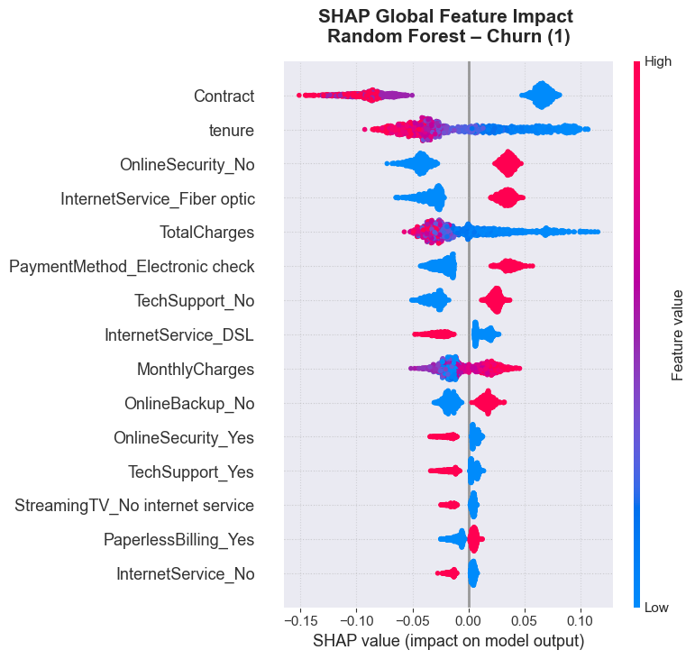

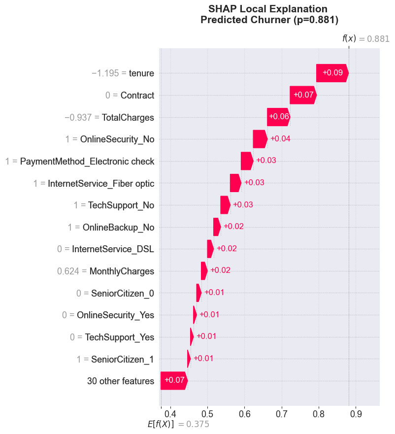

```python
explainer_shap = shap.TreeExplainer(fitted_classifier)
shap_values    = explainer_shap.shap_values(X_test_transformed)

shap_churn = shap_values[:, :, 1] if shap_values.ndim == 3 else shap_values[1]

# Global Explanation -----------------
plt.figure()
shap.summary_plot(
    shap_churn,
    X_test_transformed,
    feature_names=xai_feature_names,
    plot_type="dot",
    show=False,
    max_display=15
)
plt.title("SHAP Global Feature Impact \nRandom Forest – Churn (1)", pad=15)
plt.tight_layout()
plt.show()

# Local Explanation -----------------
shap_explanation = shap.Explanation(
    values = shap_churn[churner_idx],
    base_values = explainer_shap.expected_value[1],
    data = instance_transformed[0],
    feature_names = xai_feature_names
)

plt.figure()
shap.plots.waterfall(shap_explanation, show=False, max_display=15)
plt.title(f"SHAP Local Explanation \nPredicted Churner (p={y_proba_test[churner_idx]:.3f})", pad=15)
plt.tight_layout()
plt.show()
```

**Results** SHAP**

- **Top drivers of churn:** The three strongest contributors are `tenure` (z = −1.195, +0.09), `Contract = Month-to-month` (ordinal value 0, +0.07), and `TotalCharges` (z = −0.937, +0.06) — all pushing the prediction well above the base rate of 0.375 toward the final probability of 0.881.
- **Service add-ons confirm the risk:** The absence of `OnlineSecurity`, `TechSupport`, and `OnlineBackup` each add a further positive contribution (+0.04, +0.03, +0.02), consistent with the EDA finding that disengaged customers churn more.
- **No features push toward retention:** Every displayed feature contributes positively to the churn prediction — there is no countervailing signal in the top 15, indicating this is an unambiguously high-risk customer profile.